# Aguacate

Análisis de mercado, 1a parte

Francisco J. López para EDC Perspectiva Integral

Junio 2019

# Generalidades

El aguacate es un fruto proveniente del árbol del mismo nombre, endémico de la región que abarca desde el centro de México hasta Centroamérica con alrededor de 90 especies en el continente americano (CONABIO 2018). Por sus elevadas propiedades nutricionales y diversidad de usos industriales el aguacate se ha convertido en un fruto apreciado en el mercado internacional, por lo que su producción y comercialización se ha propagado por distintas partes del mundo.

En los sucesivo se empleará el término aguacate para hacer referencia al fruto del árbol del aguacate

En promedio 94 países tuvieron participación comercial como exportadores de aguacate y 130 como importadores durante el periodo comprendido entre los años 2008 y 2017. Prueba de lo anterior es el registro en un solo año de un máximo de 102 países exportadores de aguacate y de un máximo de 136 países con registros de importación, cifras alcanzadas en 2013 y 2008, respectivamente, dentro de un universo de 195 países (United Nations 2019). Sin embargo, en términos de los volúmenes comerciados de manera individual y valoración del fruto se puede hablar de participantes preponderantes como se verá a continuación.

# Principales jugadores

## Importadores

De un volumen estimado en 2,003,862 toneladas de aguacate correspondiente a las importaciones efectuadas en 2017, se tiene que el mercado estadounidense es por mucho el de mayor participación con poco más del 46% del total de las importaciones, seguido por Holanda, Francia, Gran Bretaña, España y Alemania que, en conjunto, concentran prácticamente el 80% de las importaciones.

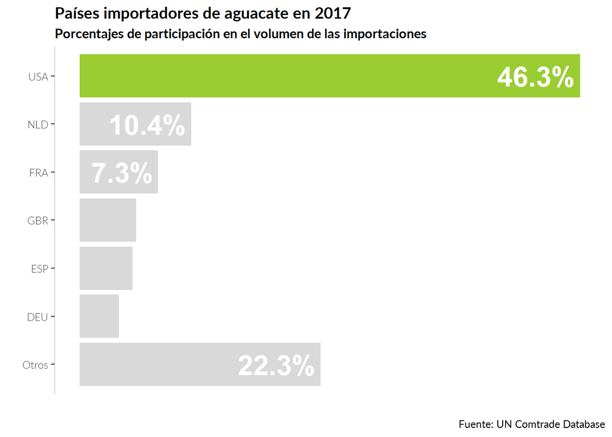

Si bien el volumen de importaciones da una idea de la magnitud física de lo comerciado, este indicador no da cuenta del aprecio de los productos en los diferentes mercados, por ello resulta conveniente revisar la prelación de las importaciones de aguacate a partir de su indicador del valor: volumen multiplicado por su precio.

Top 6 de países importadores de aguacate en 2017 (fuente: UN Comtrade Database)

| País | tons | usd_kg |
| --- | --- | --- |
| USA | 927,959 | $2.94 |
| NLD | 207,465 | $2.66 |
| FRA | 145,967 | $3.06 |
| GBR | 105,064 | $2.69 |
| ESP | 98,056 | $2.55 |
| DEU | 72,710 | $3.79 |

El único cambio observado en la posición de los países compradores de aguacate en el mercado internacional al considerar el valor como medida para su ordenación, ocurre entre España y Alemania, siendo este último el que mejora su posición, dada su mayor valoración del fruto.

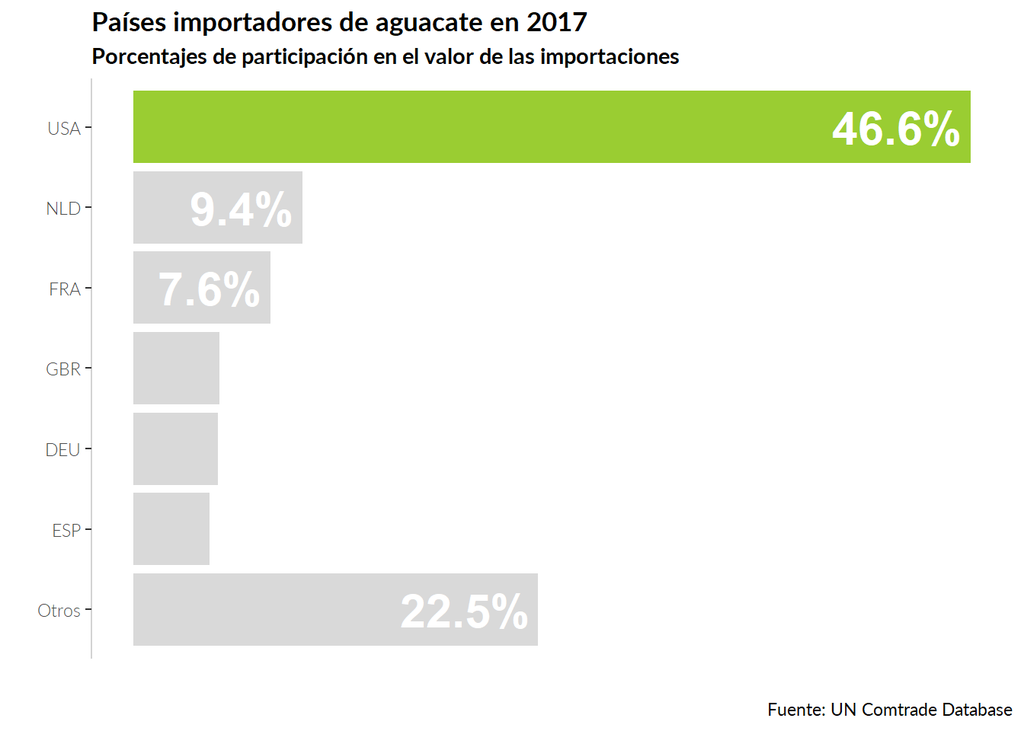

El desenvolvimiento de cada uno de los mercados es otro aspecto que deja de manifiesto el importante papel que juegan los actores principales hasta ahora identificados. La forma aquí adoptada para revisar la evolución de estos mercados a través del tiempo requiere del cálculo de la tasa de crecimiento anual promedio (TCAP) del valor de las importaciones en los últimos 10 años. Sin embargo, dada las importantes diferencias en las magnitudes de su valor, principalmente entre los Estados Unidos y el resto de los países importadores, las tasas deben ser ponderadas para de esta forma permitiendo una comparativa más precisa. Se opta por utilizar como medida de relativización la proporción del valor de las importaciones en 2017 de cada país respecto al mayor valor encontrado en ese mismo año que, en este caso, corresponde al de los Estados Unidos. A esta forma ponderada de las tasas de crecimiento se le denominará tasa de crecimiento anual promedio relativa (TCAPr).

Top 10 de países con las mayores tasas relativas de crecimiento anual promedio del valor de las importaciones de aguacate, 2010-2017 (fuente: UN Comtrade Database)

| País | TCAP | TCAPr |
| --- | --- | --- |
| USA | 17.6% | 17.6% |
| NLD | 17.3% | 3.5% |
| DEU | 22.0% | 2.2% |
| GBR | 18.1% | 1.9% |
| ESP | 17.7% | 1.6% |
| FRA | 9.1% | 1.5% |
| JPN | 11.4% | 0.9% |
| BEL | 28.1% | 0.8% |
| HKG | 40.6% | 0.8% |
| ARG | 30.2% | 0.5% |

En el top 6 de países importadores de aguacate ordenados de acuerdo a su crecimiento anual promedio relativo se encuentran los mismos participantes que en las listas ordenas por su volumen y por su valor, lo que indica que estos países no solo son atractivos en términos de su tamaño, también lo son por su estado evolutivo que se muestra aún en una fase de expansión.

Una vez identificados los principales países compradores de aguacate, puede resultar de interés abordar sus particularidades a partir de las cifras de importación con una frecuencia mensual.

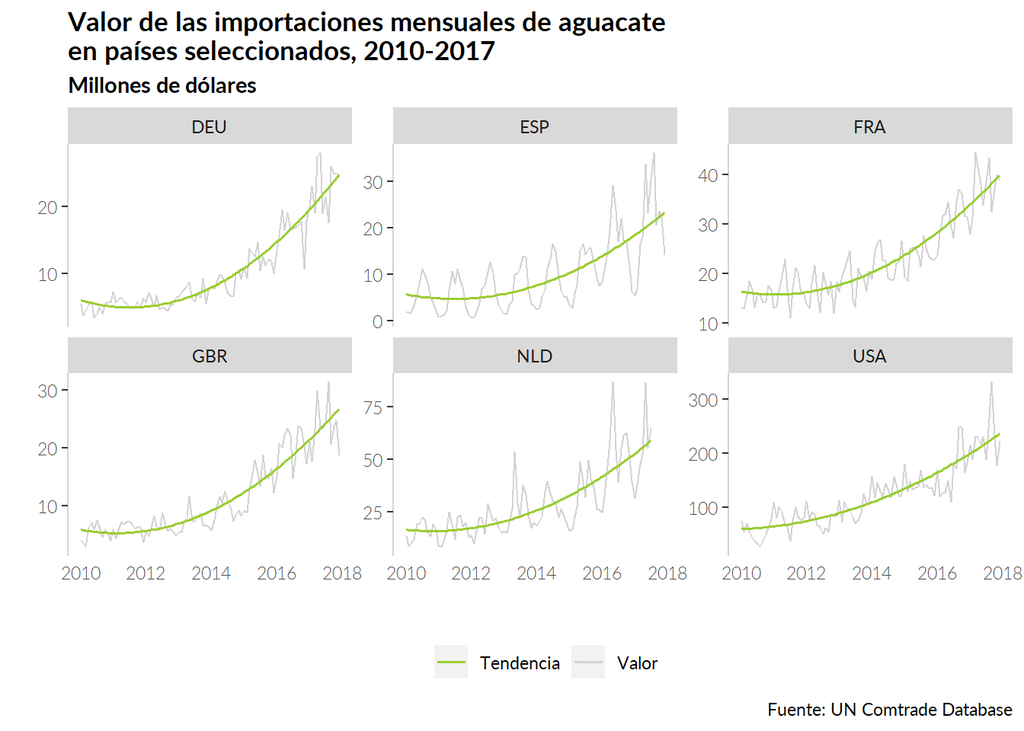

A la fecha de elaboración de este documento, los datos publicados de 2017 de las importaciones mensuales de aguacate de Holanda solo cubren de enero a julio de este año, siendo este país el único de los seis analizados que se encuentra en este caso.

La tendencia ascendente de los seis casos revisados están en concordancia con el análisis evolutivo arriba efectuado.

Aunque es de esperar un comportamiento estacional en las importaciones por efecto de los ciclos naturales del cultivo, solo en el desarrollo de la serie de las importaciones de aguacate de España se puede observar con mayor claridad este fenómeno. Sin embargo, al extraer los patrones estacionales subyacentes en cada una de las series analizadas se puede apreciar su comportamiento en cada caso.

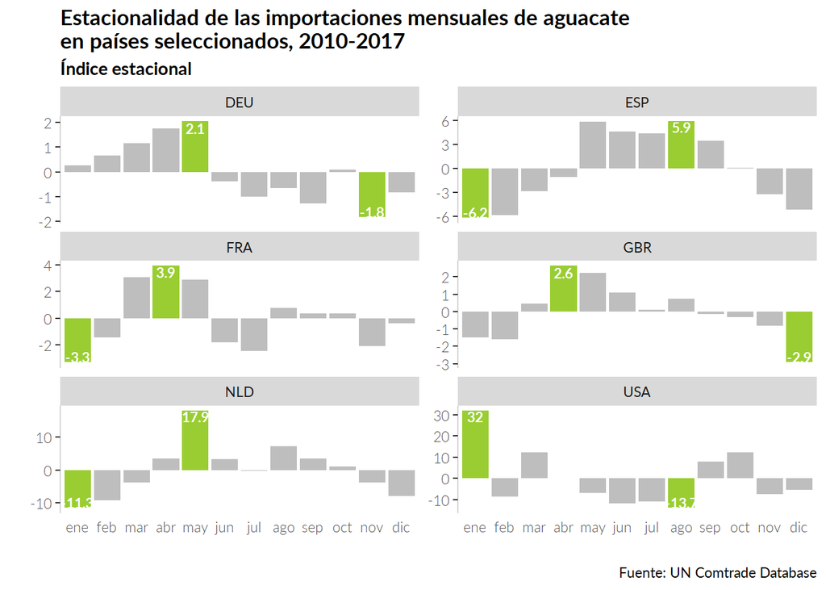

En términos generales los patrones estacionales de Alemania y Francia son similares; los de Reino Unido, Holanda y España presentan ciertas semejanzas entre sí pero en contraciclo a lo observado en los Estados Unidos, situación relacionada con la ubicación hemisférica de los abastecedores de unos y otros. Adicionalmente, si se presta atención a las magnitudes de los respectivos índices se observará a lo largo del año una mayor variabilidad en el valor de las importaciones de aguacate en países como Estados Unidos y Holanda que la que se presenta en el resto de los mercados analizados.

A modo de verificación de la presencia de proveedores contracíclicos entre los principales importadores de aguacate, así como su situación en términos de concentración, se revisan las cifras del valor de las importaciones según su origen para el año más reciente con el que se cuenta con información, este es 2017. En dicho año Francia fue el país que dentro del conjunto de los principales importadores de aguacate en el mundo mostró una mayor diversificación en el origen de sus compras de esta fruta con un total de 49 socios proveedores; en el extremo opuesto se encontró a los Estados Unidos con tan solo 5 países proveedores de aguacate.

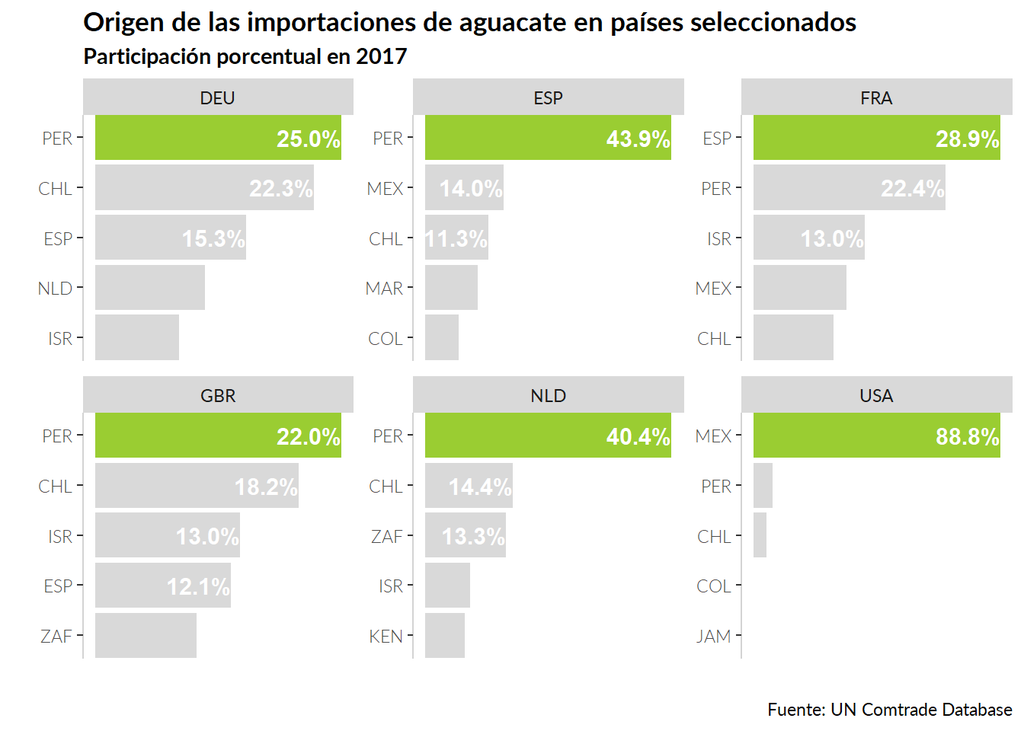

En todos los casos, los cinco países mostrados como sus principales proveedores de aguacate concentran más del 70% del total del valor de las compras de esta fruta realizadas en el exterior.

Al sustraer la tendencia y los ciclos estacionales de las series conformadas por las importaciones de aguacate de los países analizados se deja al descubierto su variabilidad a lo largo del tiempo. A manera de referencia visual, a los gráficos de las series sin tendencia y sin estacionalidad normalizadas se les incorporó una banda que tiene como límites superior e inferior la suma y sustracción de una desviación estándar a la media; de esta forma el desarrollo de una serie cuya banda presenta mayor amplitud será más volátil que otra en la que esto ocurra en menor medida.

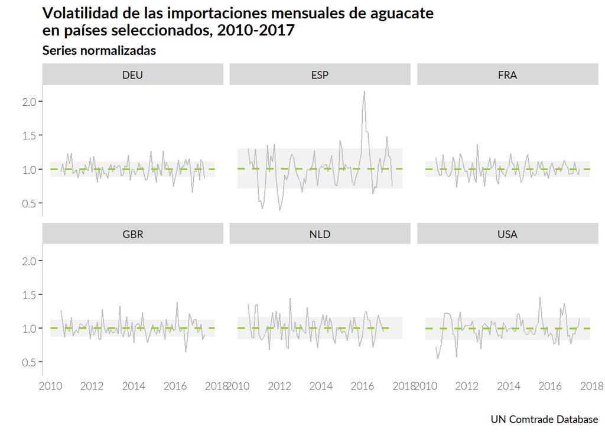

Alemania, Francia y Gran Bretaña son, dentro del conjunto de países analizados, los que presentan menor volatilidad en sus importaciones de aguacate; los mercados estadounidense y holandés muestran un mayor grado de volatilidad que los anteriores tres, siendo España el país cuyas importaciones se mostraron con la mayor variabilidad a lo largo de los 10 años considerados en esta comparativa.

La desviación estándar tanto del índice estacional de cada país como de las series desestacionalizadas, sin tendencia y normalizadas, son empleadas como medidas resumen que permiten verificar lo dicho a partir del análisis visual recién efectuado, observando que a mayor magnitud del indicador, mayor su nivel de variación.

Medidas de variación estacional y volatilidad de las importaciones de aguacate en países seleccionados, 2010-2017 (fuente: UN Comtrade Database)

| País | Estacionalidad | Volatilidad |
| --- | --- | --- |
| DEU | 1.21 | 0.11 |
| ESP | 4.68 | 0.29 |
| FRA | 2.36 | 0.12 |
| GBR | 1.59 | 0.12 |
| NLD | 8.05 | 0.17 |
| USA | 13.61 | 0.16 |

## Exportadores

Como se pudo apreciar al revisar el origen de las importaciones de aguacate, el mercado de las exportaciones de esta fruta se encuentra concentrado en más del 80% en 5 países: México, Perú, Holanda, Chile y España, debiendo aclarar que de este grupo, el único que no es productor es Holanda, que, de acuerdo al Buró Central de Estadística de este país (CBS 2017) reexporta el 79% de sus importaciones.

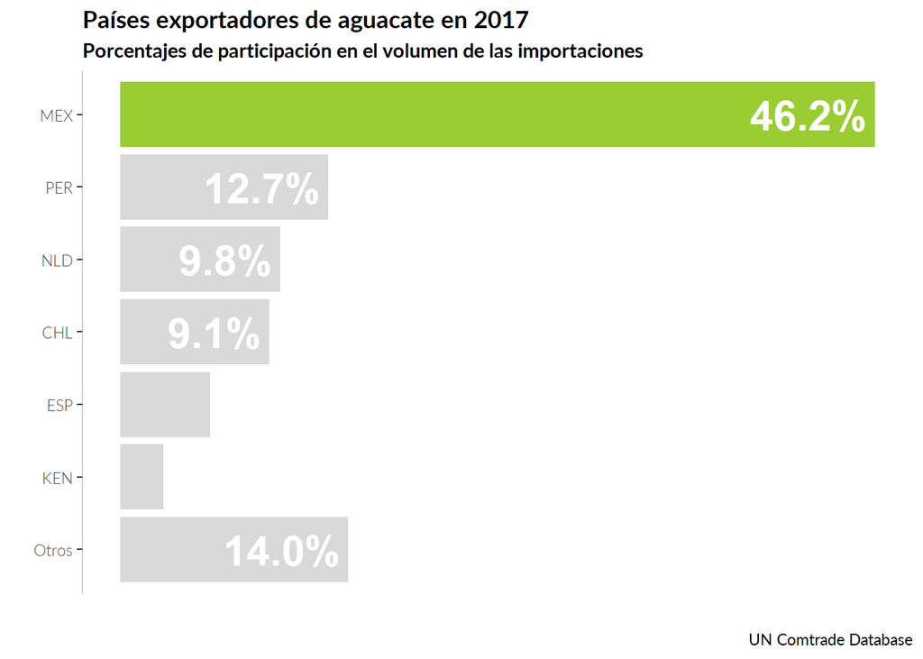

Al considerar el valor de la producción como medida para establecer el orden de los participantes en el mercado de las exportaciones de aguacate, el único cambio de posición ocurre entre Holanda y Perú, el primero mejorando su posición, situación que tiene sentido al considerar su naturaleza reexportadora.

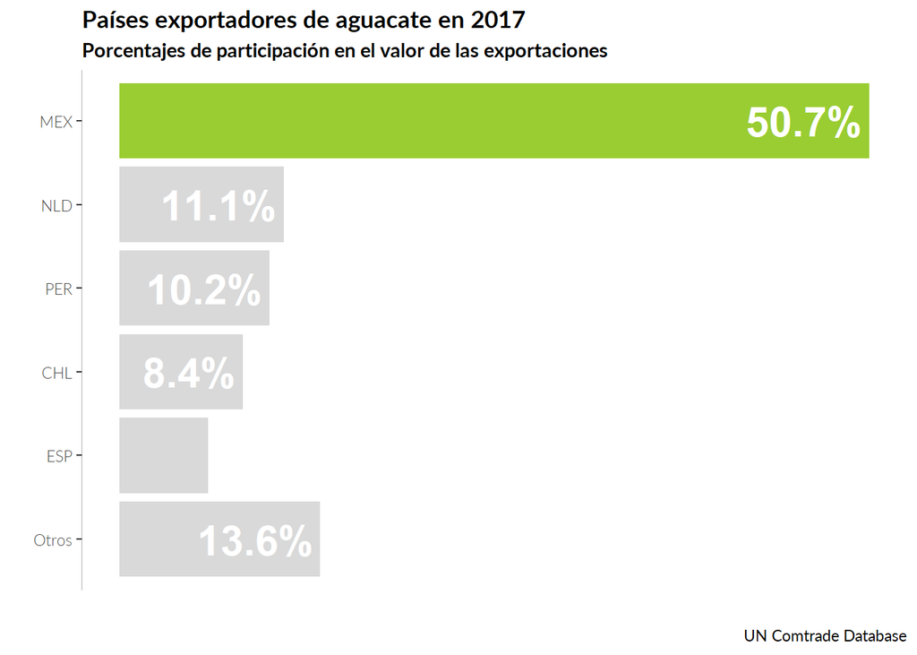

En concordancia con lo encontrado hasta este punto, la tendencia de las exportaciones de aguacate es creciente en el top cinco de países con el mayor valor en este rubro; más aún, el ritmo de crecimiento exhibido en los últimos 10 años del valor de las exportaciones de los tres principales exportadores es superior al del top de los importadores, lo que habla de la incursión de los exportadores a otros mercados como se vera más adelante.

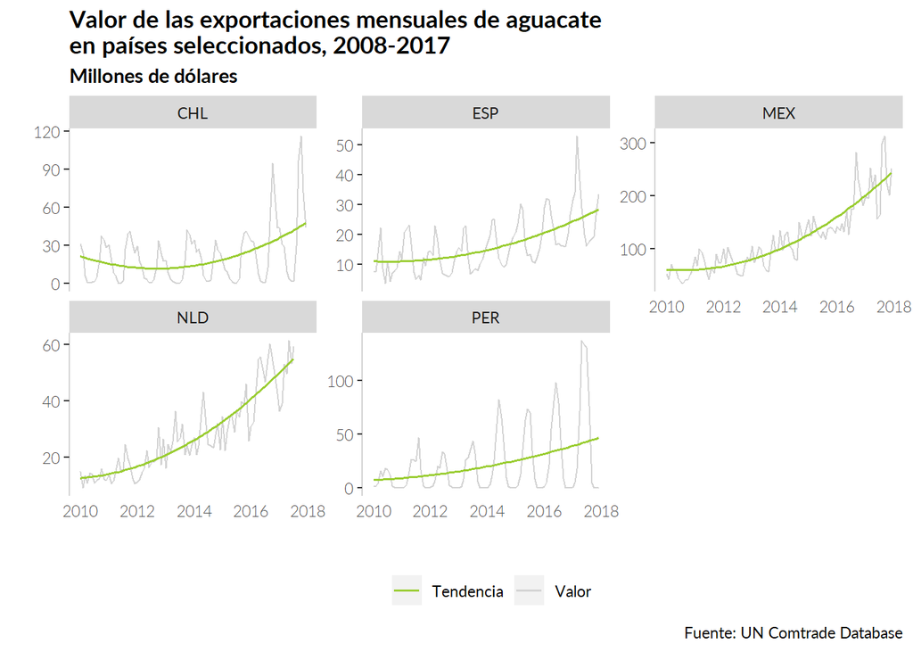

Top 10 de países con las mayores tasas relativas de crecimiento anual promedio del valor de las exportaciones de aguacate, 2010-2017 (fuente: UN Comtrade Database)

| País | TCAP | TCAPr |
| --- | --- | --- |
| MEX | 20% | 19.7% |
| PER | 28% | 5.6% |
| NLD | 21% | 4.7% |
| COL | 140% | 2.5% |
| HKG | 222% | 2.4% |
| CHL | 8% | 1.3% |
| ESP | 11% | 1.3% |
| USA | 22% | 1.2% |
| BEL | 35% | 0.5% |
| MAR | 32% | 0.5% |

En efecto, dentro del destino de las exportaciones de aguacate de los comercializadores latinoamericanos se observa la presencia de otros mercados como lo son el chino para el caso de las exportaciones de Perú y Chile y la presencia de Japón como comprador relevante del aguacate proveniente de México.

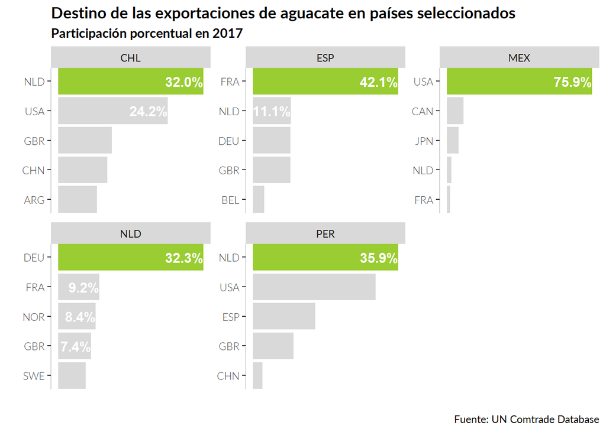

Con respecto a la ciclicidad intranual, se observa que México y España guardan un patrón estacional parecido, alcanzando ambos su mayor valor de las exportaciones durante el mes de marzo; las ventas de aguacate de Perú al exterior exhiben su nivel máximo en el mes de junio y con un desfase de cuatro meses las exportaciones chilenas alcanzan su máximo durante el año.

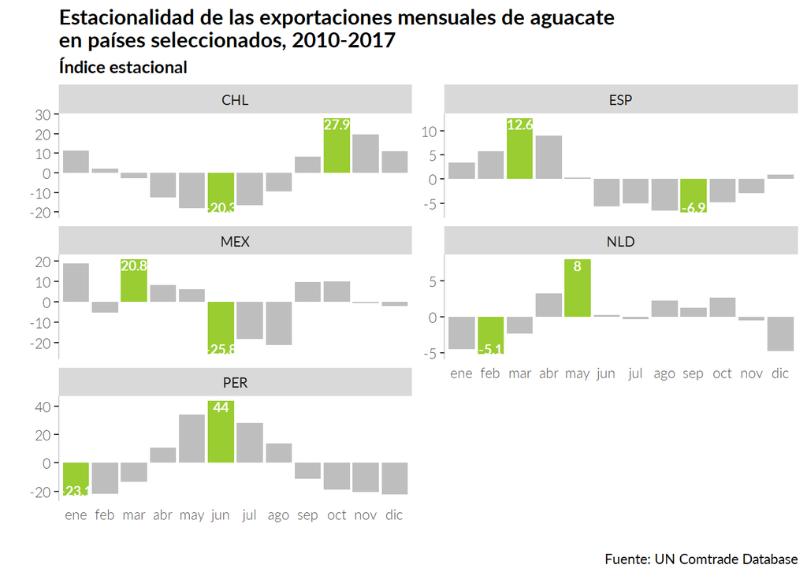

Haciendo a un lado las tendencias alcistas y los patrones estacionales presentes en las exportaciones del top cinco de países oferentes de aguacate, se observa una elevada volatilidad en Perú y Chile, mostrando el resto de los países una mayor estabilidad durante el periodo analizado.

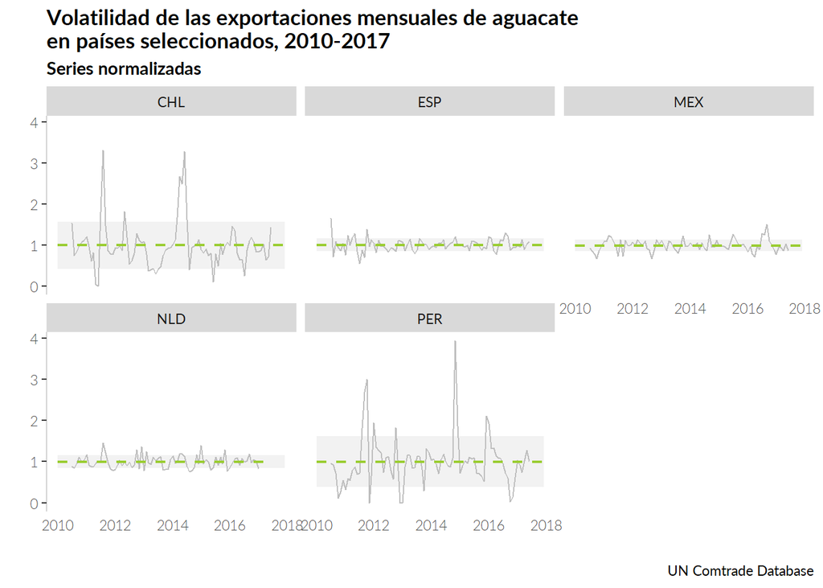

El cálculo de la desviación estándar estacional y de las series desestacionalizadas y sin tendencia de las exportaciones de aguacate confirman lo hasta ahora dicho tras su inspección visual.

Medidas de variación estacional y volatilidad de las exportaciones de aguacate en países seleccionados, 2010-2017 (fuente: UN Comtrade Database)

| País | Estacionalidad | Volatilidad |
| --- | --- | --- |
| CHL | 15.86 | 0.57 |
| ESP | 6.48 | 0.16 |
| MEX | 15.32 | 0.15 |
| NLD | 3.84 | 0.15 |
| PER | 24.89 | 0.61 |

# Referencias

CBS, Centraal Bureau de Statistiek. 2017. “Netherlands Second Largest Avocado Importer Worlwide.” https://www.cbs.nl/en-gb/news/2017/19/netherlands-second-largest-avocado-importer-worldwide.

CONABIO, Comisión Nacional para el Conocimiento y Uso de la Biodiversidad. 2018. “Biodiversidad Mexicana, Aguacate.” https://www.biodiversidad.gob.mx/usos/alimentacion/aguacate.html.

United Nations. 2019. “UN Comtrade Database.” https://comtrade.un.org/data/.